# Project for Practical Machine Learning

**INTRODUCTION and SUMMARY:**

I’ll follow the steps outlined in lecture 1-2. In particular this report is roughly organized along the steps:

1. Question
2. Input Data
3. Features
4. Algorithm
5. Parameters
6. Evaluation

The question is to estimate the “classe” classification, given the other input data. The input data was given, but had to be cleaned up - 2 sample outliers (they were “way out”) were removed. The selected features were just the variables that were NOT mostly blank. I started with the Random Forest algorithm. Although it turned out not to be necessary (the first model worked well enough), the methodology was followed, and two different parameter settings for the Random Forest algorithm were considered. The data was split 3 ways into training, validation and test sets, where the training data was used to create the model, the validation data was used to select between to two different parameter settings, and the test data was used as a final sanity check.

Then the resulting model was used to predict the supplied test set, those predictions were submitted to the grading program.

**INPUT DATA:**

First set up the environment

```r
setwd("c:/home/willy/coursera/practicalml/project")
library(caret)
library(randomForest)
set.seed(440)
```

Next, get the data into the system -

```r
pmltraining = read.csv("pml-training.csv")
```

and find that there are 160 variables (including classe) and 19622 samples.

First check to see if the data is reasonable. Using Excel to view the data in a spreadsheet format reveals much of the structure (or lack of structure). I found the plotting Excel to be marginally faster than doing qplots. In any case, each variable was plotted just to see how good the data was. I found that samples 5374 and 9275 were outliers in that the values they had seemed to be very different relative to their neighbors. You can see this in R by plotting the affected variables

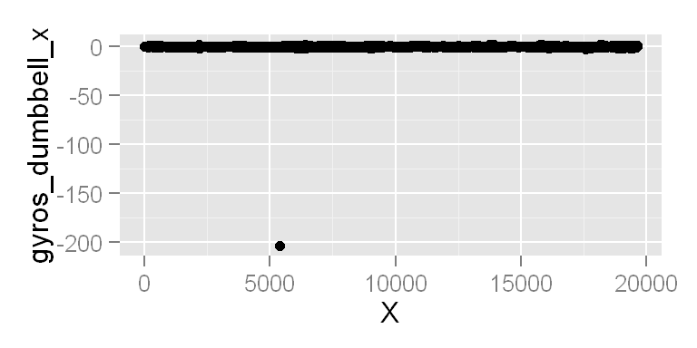

```r
qplot(X,gyros_dumbbell_x,data=pmltraining)
```

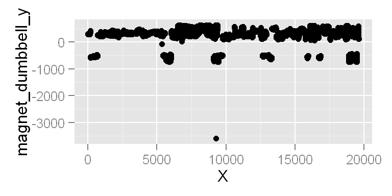

```r
qplot(X,magnet_dumbbell_y,data=pmltraining)
```

It is important to point out that just about all the variables looked like the two plotted above, in that there was no discernable “blockyness” in the values - that is the clustering of the variable values, for a given value of classe, which would form a “block” on the plot. The blockyness would show up, since the classe variables are ordered with like values adjacent to each other. If this “blockyness” had shown up, I could have tried a model that only included the blocky variables. Alas, no blockiness, so I have to consider all these variables.

The outlier samples were eliminated using the following command

```r
pmltrainingclean <- pmltraining[-c(5373,9274),]
```

and replotted to make sure it was done right.

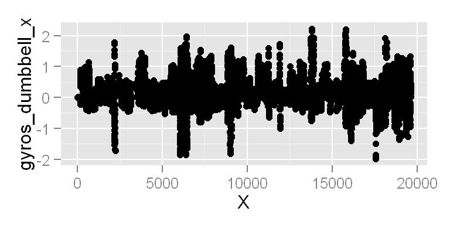

```r
qplot(X,gyros_dumbbell_x,data=pmltrainingclean)
```

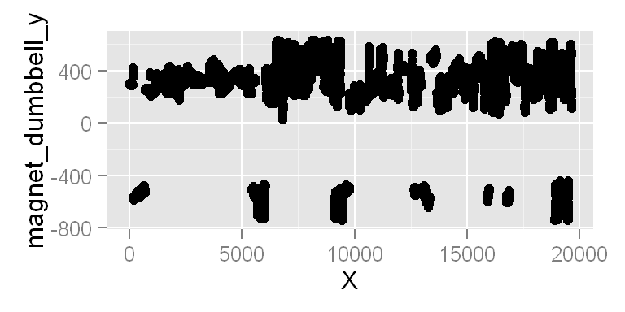

```r
qplot(X,magnet_dumbbell_y,data=pmltrainingclean)
```

**FEATURE SELECTION:**

Feature selection in this case involved no preprocessing, only selecting the variables that had mostly good values.

Doing a “names(pmltrainingclean)” Gives a response (truncated here):

[1] “X” “user_name”  
[3] “raw_timestamp_part_1” “raw_timestamp_part_2”  
[5] “cvtd_timestamp” “new_window”  
[7] “num_window” “roll_belt”  
[9] “pitch_belt” “yaw_belt”  
[11] “total_accel_belt” “kurtosis_roll_belt”

From this it is clear I need to make a stripped training set, which doesn’t have variables 1-7 in it, which shouldn’t be related to what we are trying to predict. This is done with the following code…

```r
exclunames <- names(pmltrainingclean) %in% c("X", "user_name", "raw_timestamp_part_1", "raw_timestamp_part_2", "cvtd_timestamp", "new_window", "num_window")
pmltrainexclu <- pmltrainingclean[!exclunames]
```

Running the command “names” verifies that those variables have been removed from the pmltrainexclu data. Also, note that the number of variables in the training set is 153 (160 - 7).

Next I look at the remaining data, and find that there are alot of NA values. In particular, with the following code I determined that there are 67 variables with more than 15000 NA’s in the column! These variables were defined only when the “new window” variable was yes, and didn’t seem to have any relationship to the classe variable (nor does “new window”=yes show up in the assignement test set!). I did plot a few of these variables in hopes that they would have values that would directly determine the classe variable, but this was not the case, from an example plot below - I was looking for the “blockyness” that I describe above, none was found.

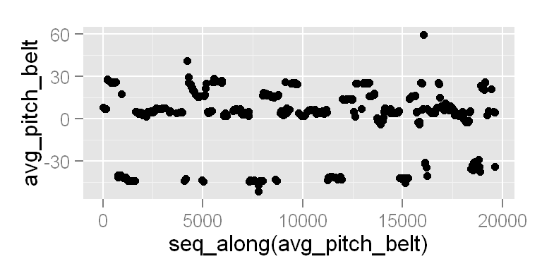

```r
qplot(,avg_pitch_belt,data=pmltrainingclean)
```

```r
count = 0
pmltrainexclunames <- names(pmltrainexclu)
for (i in 1:length(pmltrainexclunames) ) {
if (sum(is.na(pmltrainexclu[ which(colnames(pmltrainexclu) == pmltrainexclunames[i])])) > 15000)  {count = count + 1}
}
cat("Total number of columns with NA in more than 15000 samples is ",count)
```

```
## Total number of columns with NA in more than 15000 samples is  67
```

Looking at the raw .csv data file, there are also many “” entries as well, that carry no value…so these are recoded to NA

```r
pmltrainexclu1 = pmltrainexclu
for (i in 1:length(pmltrainexclunames) ) {
pmltrainexclu1[which(colnames(pmltrainexclu) == pmltrainexclunames[i])] [pmltrainexclu[which(colnames(pmltrainexclu) == pmltrainexclunames[i])] == ""] <- NA
}
```

Then find them again…

```r
count = 0
for (i in 1:length(pmltrainexclunames) ) {
if (sum(is.na(pmltrainexclu1[ which(colnames(pmltrainexclu1) == pmltrainexclunames[i])])) > 15000)  {count= count + 1}
}
cat(" Total number of columns containing > 15000 blank or NA values is ", count)
```

```
##  Total number of columns containing > 15000 blank or NA values is  100
```

with all of these converted, I have 100 columns of possible junk. So these columns are eliminated.

```r
pmltrainexclu2 = pmltrainexclu1
for (i in 1:length(pmltrainexclunames) ) {
if (sum(is.na(pmltrainexclu1[ which(colnames(pmltrainexclu1) == pmltrainexclunames[i])])) > 15000)  {
exclunamestemp <- names(pmltrainexclu2) %in% pmltrainexclunames[i]
pmltrainexclu2 <- pmltrainexclu2[!exclunamestemp] }
}
```

Doing a “names” on pmltrainexclu2 gives us 53 variables (including the classe variable).

```r
names(pmltrainexclu2)
```

```
##  [1] "roll_belt"            "pitch_belt"           "yaw_belt"
##  [4] "total_accel_belt"     "gyros_belt_x"         "gyros_belt_y"
##  [7] "gyros_belt_z"         "accel_belt_x"         "accel_belt_y"
## [10] "accel_belt_z"         "magnet_belt_x"        "magnet_belt_y"
## [13] "magnet_belt_z"        "roll_arm"             "pitch_arm"
## [16] "yaw_arm"              "total_accel_arm"      "gyros_arm_x"
## [19] "gyros_arm_y"          "gyros_arm_z"          "accel_arm_x"
## [22] "accel_arm_y"          "accel_arm_z"          "magnet_arm_x"
## [25] "magnet_arm_y"         "magnet_arm_z"         "roll_dumbbell"
## [28] "pitch_dumbbell"       "yaw_dumbbell"         "total_accel_dumbbell"
## [31] "gyros_dumbbell_x"     "gyros_dumbbell_y"     "gyros_dumbbell_z"
## [34] "accel_dumbbell_x"     "accel_dumbbell_y"     "accel_dumbbell_z"
## [37] "magnet_dumbbell_x"    "magnet_dumbbell_y"    "magnet_dumbbell_z"
## [40] "roll_forearm"         "pitch_forearm"        "yaw_forearm"
## [43] "total_accel_forearm"  "gyros_forearm_x"      "gyros_forearm_y"
## [46] "gyros_forearm_z"      "accel_forearm_x"      "accel_forearm_y"
## [49] "accel_forearm_z"      "magnet_forearm_x"     "magnet_forearm_y"
## [52] "magnet_forearm_z"     "classe"
```

**ALGORITHM and PARAMETERS:**

Next, I examine the training variable to be predicted - “classe”

```r
summary(pmltrainexclu2$classe)
```

```
##    A    B    C    D    E
## 5579 3796 3422 3216 3607
```

It is distributed fairly evenly.

Since I may have to try different models to get to a final one, I need to divide the given training data up into three sets - a training, validation and test set. The test set will only be used once at the end, to make sure I am not doing something stupid.

For validation & test, this training set will be have to split into a training (60%) validation (20%) and test (20%) set, so I can tune my design on the validation set, and then run a final test on the test set.

```r
inTrain <- createDataPartition(pmltrainexclu2$classe,p=0.6,list=FALSE)
pmltrain <- pmltrainexclu2[inTrain,]
pmlvt <- pmltrainexclu2[-inTrain,]
inValid <- createDataPartition(pmlvt$classe,p=0.5,list=FALSE)
pmlvalid <- pmlvt[inValid,]
pmltest <- pmlvt[-inValid,]
```

Now I am ready to try my first model. I pick Random Forest because of lecture 3-3 where it is praised for its accuracy. Given that there is no obvious trend or relationship between the data and the classe variable, we need all the accuracy we can get! I make sure I’ve got lots of memory available… 52 variables should fit… but following the advice of the forums I will not use the “train” function in caret, instead, I will just use the “randomForest” call directly.

```r
modFitset1 <- randomForest(pmltrain$classe ~ ., data=pmltrain)
```

Then I want to assess performance with the validation set with

```r
validset1pred <- predict(modFitset1, pmlvalid)
validset1right <- validset1pred == pmlvalid$classe
table(validset1right)
```

```
## validset1right
## FALSE  TRUE
##    21  3902
```

A confusion matrix listing gives the following:

```r
confusionMatrix(data=pmlvalid$classe, validset1pred)
```

```
## Confusion Matrix and Statistics
##
##           Reference
## Prediction    A    B    C    D    E
##          A 1116    0    0    0    0
##          B    1  756    2    0    0
##          C    0    4  680    0    0
##          D    0    0   11  632    0
##          E    0    0    0    3  718
##
## Overall Statistics
##
##                Accuracy : 0.9946
##                  95% CI : (0.9918, 0.9967)
##     No Information Rate : 0.2847
##     P-Value [Acc > NIR] : < 2.2e-16
##
##                   Kappa : 0.9932
##  Mcnemar's Test P-Value : NA
##
## Statistics by Class:
##
##                      Class: A Class: B Class: C Class: D Class: E
## Sensitivity            0.9991   0.9947   0.9812   0.9953   1.0000
## Specificity            1.0000   0.9991   0.9988   0.9967   0.9991
## Pos Pred Value         1.0000   0.9960   0.9942   0.9829   0.9958
## Neg Pred Value         0.9996   0.9987   0.9960   0.9991   1.0000
## Prevalence             0.2847   0.1937   0.1767   0.1619   0.1830
## Detection Rate         0.2845   0.1927   0.1733   0.1611   0.1830
## Detection Prevalence   0.2845   0.1935   0.1744   0.1639   0.1838
## Balanced Accuracy      0.9996   0.9969   0.9900   0.9960   0.9995
```

This confusion matrix output tells us that the classifier is pretty good. The out of sample error is minimal, at 99.5%+ accuracy its going to do as well as I could expect on the real test values. That error rate also is verified by the ratio of “trues” in the validset1right vector shown above.

```r
modFitset2 <- randomForest(pmltrain$classe ~ ., data=pmltrain, ntrees=1500)
```

which gave marginally better results, as shown by the confusion matrix.

```r
validset2pred <- predict(modFitset2, pmlvalid)
validset2right <- validset2pred == pmlvalid$classe
table(validset2right)
```

```
## validset2right
## FALSE  TRUE
##    20  3903
```

```r
confusionMatrix(data=pmlvalid$classe, validset2pred)
```

```
## Confusion Matrix and Statistics
##
##           Reference
## Prediction    A    B    C    D    E
##          A 1116    0    0    0    0
##          B    0  756    3    0    0
##          C    0    5  679    0    0
##          D    0    0    9  634    0
##          E    0    0    0    3  718
##
## Overall Statistics
##
##                Accuracy : 0.9949
##                  95% CI : (0.9921, 0.9969)
##     No Information Rate : 0.2845
##     P-Value [Acc > NIR] : < 2.2e-16
##
##                   Kappa : 0.9936
##  Mcnemar's Test P-Value : NA
##
## Statistics by Class:
##
##                      Class: A Class: B Class: C Class: D Class: E
## Sensitivity            1.0000   0.9934   0.9826   0.9953   1.0000
## Specificity            1.0000   0.9991   0.9985   0.9973   0.9991
## Pos Pred Value         1.0000   0.9960   0.9927   0.9860   0.9958
## Neg Pred Value         1.0000   0.9984   0.9963   0.9991   1.0000
## Prevalence             0.2845   0.1940   0.1761   0.1624   0.1830
## Detection Rate         0.2845   0.1927   0.1731   0.1616   0.1830
## Detection Prevalence   0.2845   0.1935   0.1744   0.1639   0.1838
## Balanced Accuracy      1.0000   0.9962   0.9905   0.9963   0.9995
```

**EVALUATION:**

The best performance was with model #2, so I use it to predict the pmltest set that we created and get a final sanity check on the model that I’m going to use for the assignment test cases.

```r
testpred <- predict(modFitset2, pmltest)
testright <- testpred == pmltest$classe
table(testright)
```

```
## testright
## FALSE  TRUE
##    23  3899
```

```r
confusionMatrix(data=pmltest$classe, testpred)
```

```
## Confusion Matrix and Statistics
##
##           Reference
## Prediction    A    B    C    D    E
##          A 1115    0    0    0    0
##          B    1  756    2    0    0
##          C    0    5  679    0    0
##          D    0    0   11  632    0
##          E    0    0    0    4  717
##
## Overall Statistics
##
##                Accuracy : 0.9941
##                  95% CI : (0.9912, 0.9963)
##     No Information Rate : 0.2845
##     P-Value [Acc > NIR] : < 2.2e-16
##
##                   Kappa : 0.9926
##  Mcnemar's Test P-Value : NA
##
## Statistics by Class:
##
##                      Class: A Class: B Class: C Class: D Class: E
## Sensitivity            0.9991   0.9934   0.9812   0.9937   1.0000
## Specificity            1.0000   0.9991   0.9985   0.9967   0.9988
## Pos Pred Value         1.0000   0.9960   0.9927   0.9829   0.9945
## Neg Pred Value         0.9996   0.9984   0.9960   0.9988   1.0000
## Prevalence             0.2845   0.1940   0.1764   0.1622   0.1828
## Detection Rate         0.2843   0.1928   0.1731   0.1611   0.1828
## Detection Prevalence   0.2843   0.1935   0.1744   0.1639   0.1838
## Balanced Accuracy      0.9996   0.9962   0.9898   0.9952   0.9994
```

This gives similar results to the validation case, namely that the out of sample error will be around 99.5% which should get us a perfect score on a sample of 20 (the number of assignment test cases). The testright table verifies this as well.

Finally, to predict the assignment test case values, I do the following:

```r
pmltesting = read.csv("pml-testing.csv")
testing2pred <- predict(modFitset2, pmltesting)
testing2pred
```

```
##  1  2  3  4  5  6  7  8  9 10 11 12 13 14 15 16 17 18 19 20
##  B  A  B  A  A  E  D  B  A  A  B  C  B  A  E  E  A  B  B  B
## Levels: A B C D E
```

which finds the values for the test set, that are to be submitted. The answers were dumped using the provided function…

```r
pml_write_files = function(x) {
    n = length(x)
    for(i in 1:n) {
      filename = paste0("problem_id_",i,".txt")
      write.table(x[i],file=filename,quote=FALSE,row.names=FALSE,col.names=FALSE)
    }
}
```

by calling it with the predictor output

```r
pml_write_files(testing2pred)
```

the submissions were all correct.